# Effects of automatic and manual transmission on MPG

## Conclusion

The first question to answer is:

- Is an automatic or manual transmission better for MPG

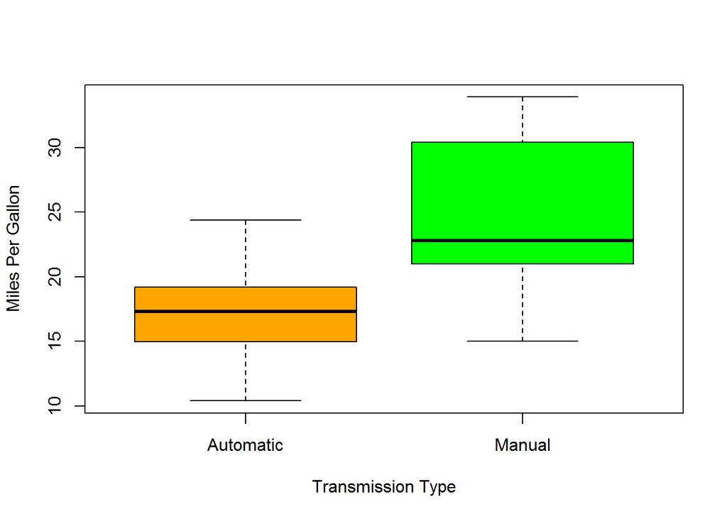

```r
boxplot(mpg ~ am, data = mtcars, col = (c("orange","green")), names = c("Automatic", "Manual"), ylab = "Miles Per Gallon", xlab = "Transmission Type")
```

From the box plot above we can see that Manual transmissions vehicles have better MPG

The second question to answer:

- Quantify the MPG difference between automatic and manual transmissions

```r
fit <- lm(mpg ~ am, data = mtcars)
coef(summary(fit))
```

```
##              Estimate Std. Error   t value     Pr(>|t|)
## (Intercept) 17.147368   1.124603 15.247492 1.133983e-15
## am           7.244939   1.764422  4.106127 2.850207e-04
```

From the linear model,

- The average MPG for automatic transmissions is 17.147 MPG (Which is also illustrated in the boxplot above), and
- We can calculate the average MPG for manual transmissions as 24.392 MPG (7.245 + 17.147).
- To answer the question above, the MPG difference between automatic and manual transmission is 7.245 MPG;

```r
summary(fit)
```

```
##
## Call:
## lm(formula = mpg ~ am, data = mtcars)
##
## Residuals:
##     Min      1Q  Median      3Q     Max
## -9.3923 -3.0923 -0.2974  3.2439  9.5077
##
## Coefficients:
##             Estimate Std. Error t value Pr(>|t|)
## (Intercept)   17.147      1.125  15.247 1.13e-15 ***
## am             7.245      1.764   4.106 0.000285 ***
## ---
## Signif. codes:  0 '***' 0.001 '**' 0.01 '*' 0.05 '.' 0.1 ' ' 1
##
## Residual standard error: 4.902 on 30 degrees of freedom
## Multiple R-squared:  0.3598, Adjusted R-squared:  0.3385
## F-statistic: 16.86 on 1 and 30 DF,  p-value: 0.000285
```